# Mhd Haekal Hakim_Tugas Pertemuan 5

Mhd Haekal Hakim

2025-10-02

## Library

```r
library(tseries)
```

```r
library(ggplot2)
library(tsibble)
library(MASS)
library(readxl)
```

## Data

```r
## Baca Data
data <- read_excel("C:/Users/mhdha/OneDrive/Dokumen/IPB/Semester 5/MPDW/JKSE_Close_Weekly.xlsx")

data1 <- data[518:775, ]
data1
```

```
## # A tibble: 258 × 2
##    Date                Close
##    <dttm>              <dbl>
##  1 2015-08-17 00:00:00 4336.
##  2 2015-08-24 00:00:00 4446.
##  3 2015-08-31 00:00:00 4415.
##  4 2015-09-07 00:00:00 4360.
##  5 2015-09-14 00:00:00 4380.
##  6 2015-09-21 00:00:00 4209.
##  7 2015-09-28 00:00:00 4208.
##  8 2015-10-05 00:00:00 4589.
##  9 2015-10-12 00:00:00 4522.
## 10 2015-10-19 00:00:00 4653.
## # ℹ 248 more rows
```

### Mengambil Data Train

```r
n <- nrow(data1)              # jumlah data = 258
n_train <- floor(0.8 * n)  # train = 206
dt_rg <- data1$`Close`[1:n_train] |> ts()
```

### Membuat Plot Data Time Series

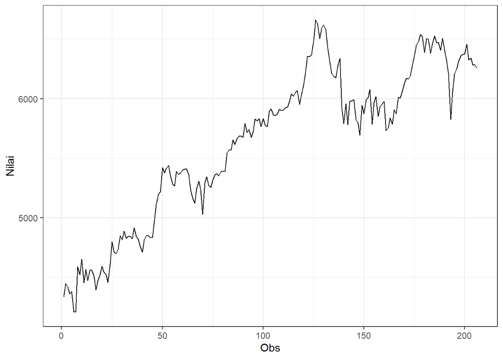

```r
dt_rg |> as_tsibble() |>
  ggplot(aes(x = index, y = value)) +
  geom_line() + theme_bw() +
  xlab("Obs") + ylab("Nilai")
```

Berdasarkan plot time series tersebut, terlihat bahwa data tidak stasioner dalam rataan, ditandai dengan adanya trend pada data dan tidak stasioner dalam ragam, ditandai dengan adanya perbedaan lebar pita pada plot

#### Uji ACF

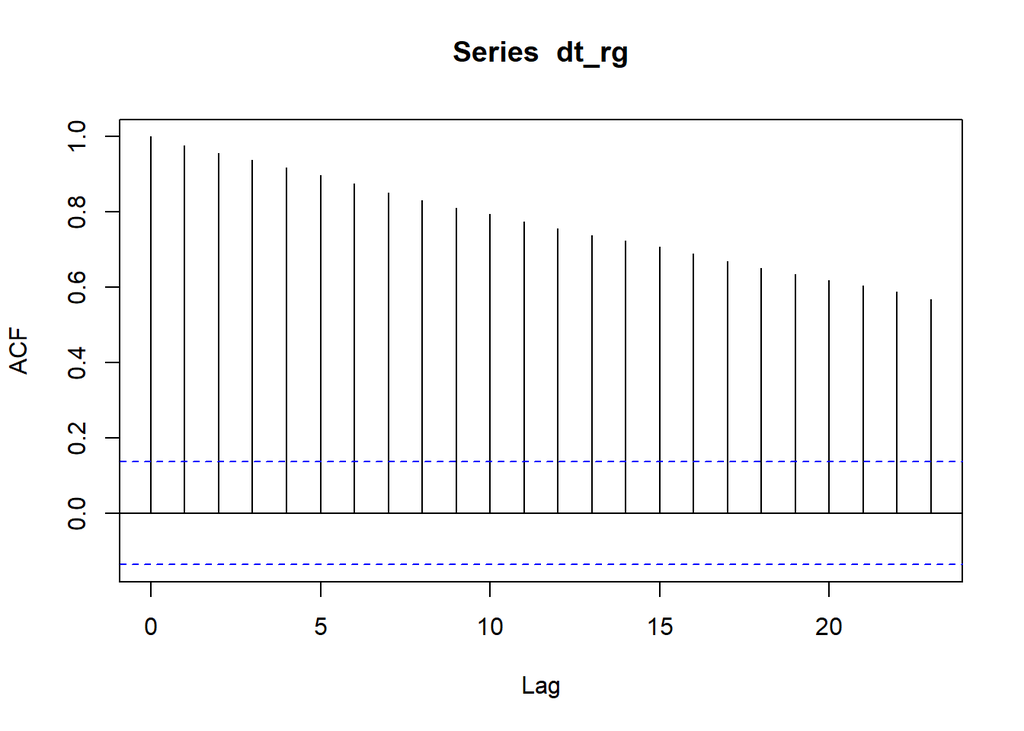

```r
acf(dt_rg)
```

Berdasarkan plot ACF, terlihat bahwa plot ACF pada data tersebut menurun secara perlahan (*tails off slowly*) yang menandakan data tidak stasioner dalam rataan

#### Uji ADF

```r
adf.test(dt_rg)
```

```
##
##  Augmented Dickey-Fuller Test
##
## data:  dt_rg
## Dickey-Fuller = -2.1811, Lag order = 5, p-value = 0.5002
## alternative hypothesis: stationary
```

$H_0$: Data tidak stasioner dalam rataan

$H_1$: Data stasioner dalam rataan

Berdasarkan uji ADF tersebut, didapat p-value sebesar 0.5002 yang lebih besar dari taraf nyata 5% dan menandakan bahwa data tidak stasioner dalam rataan. Hal ini sesuai dengan hasil eksplorasi menggunakan plot time series dan plot ACF.

### Uji Box-cox

```r
# Bikin Index
index <- seq_along(dt_rg)
```

```r
# Buat Data Supaya Positif
shift_val <- abs(min(dt_rg)) + 1
dt_rg_shift <- dt_rg + shift_val
```

```r
# Regresi Linear untuk Box-Cox
lm_bc <- lm(dt_rg_shift ~ index)
```

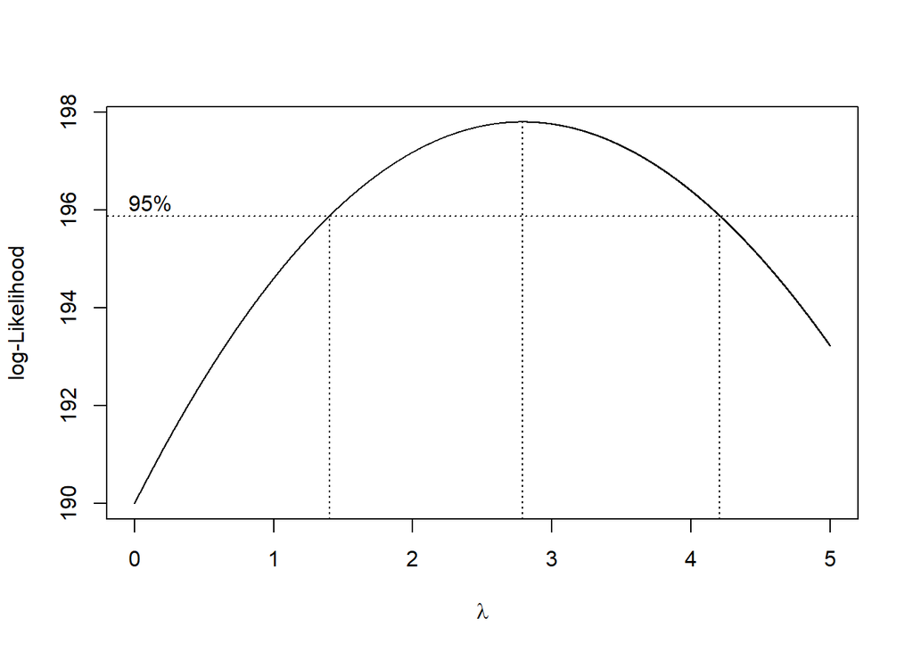

```r
# Uji Box-Cox
bc <- boxcox(lm_bc, lambda = seq(0, 5, by = 0.001))
```

```r
# Cari Lambda Optimum
lambda_opt <- bc$x[which.max(bc$y)]
ci_lambda <- bc$x[bc$y > max(bc$y) - 0.5 * qchisq(0.95, 1)]

cat("Lambda Optimum:", lambda_opt, "\n")
```

```
## Lambda Optimum: 2.788
```

```r
cat("95% CI Lambda:", min(ci_lambda), "-", max(ci_lambda), "\n")
```

```
## 95% CI Lambda: 1.402 - 4.206
```

### Differencing

```r
dt_rg_diff1 <- diff(dt_rg, differences = 1)
```

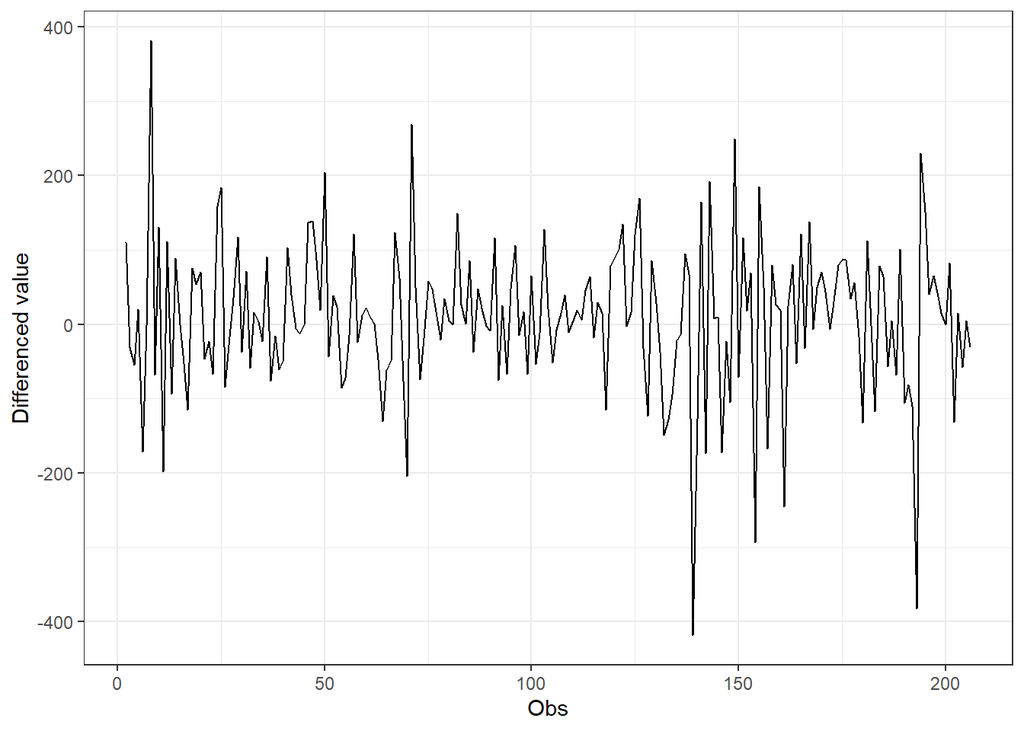

```r
dt_rg_diff1 |> as_tsibble() |>
  ggplot(aes(x = index, y = value)) +
  geom_line() + theme_bw() +
  xlab("Obs") + ylab("Differenced value")
```

#### Cek ACF dan ADF

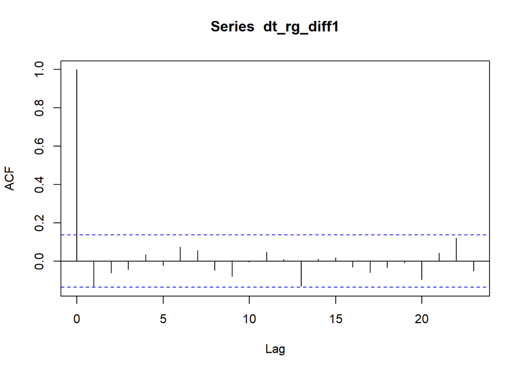

```r
acf(dt_rg_diff1)
```

Berdasarkan plot ACF, terlihat bahwa plot ACF pada data tersebut berada dalam rentang yang menandakan bahwa data stasioner dalam rataan

```r
adf.test(dt_rg_diff1)
```

```
##
##  Augmented Dickey-Fuller Test
##
## data:  dt_rg_diff1
## Dickey-Fuller = -5.882, Lag order = 5, p-value = 0.01
## alternative hypothesis: stationary
```

$H_0$: Data tidak stasioner dalam rataan

$H_1$: Data stasioner dalam rataan

Berdasarkan uji ADF tersebut, didapat p-value sebesar 0.01 yang lebih kecil dari taraf nyata 5% dan menandakan bahwa data stasioner dalam rataan. Hal ini sesuai dengan hasil eksplorasi menggunakan plot time series dan plot ACF.